# Laboratorio 1: Exploración de Datos y Regresión Lineal

Fundamentos de la Analítica de Datos

Felipe Catalan

2022-10-15

## Objetivo y contexto

El siguiente laboratorio tiene como objetivo aplicar técnicas de descripción estadísticas y regresión lineal.La base en la que se trabajará es *Movie.xlsx*, la que contiene datos sobre el número de agresiones y asistencia al cine para 518 fines de semanas. Esta base intenta responder a la pregunta, si **¿la violencia en el cine aumenta el crimen violento?**.

La metadata es:

- *assaults:* Número de asaltos e intimidación en Estados Unidos.
- *attend_v:* Asistencia a películas violentas (en millones).
- *attend_m:* Asistencia a películas con violencia media (en millones).
- *attend_n:* Asistencia a películas no violentas(en millones).
- *year1:* Variable dummy que indica los años de la muestra en estudio (1995-2004).
- *month1:* Variable dummy que indica los meses del año (enero-diciembre).
- *h_chris:* Variable dummy que indica el fin de semana de navidad (1 es que sí).
- *h_newyr:* Variable dummy que indica el fin de semana de año nuevo (1 es que sí).
- *h_easter:* Variable dummy que indica el fin de semana de semana santa (1 es que sí).
- *h_july4:* Variable dummy que indica el fin de semana del 4 de Julio (1 es que sí).
- *w_rain:* Franción de lugares con lluvia.
- *w_snow:* Franción de lugares con Nieve.
- *w_maxa:* Franción de lugares con una temperatura máxima diaria entre 80°F y 90°F.
- *w_maxb:* Franción de lugares con una temperatura máxima diaria entre 90°F y 100°F.
- *w_maxc:* Franción de lugares con una temperatura máxima diaria más de 100°F.
- *w_mina:* Franción de lugares con una temperatura mínima diaria entre 0° y 10 °F.
- *w_minb:* Franción de lugares con una temperatura mínima diaria entre 10° y 20 °F.
- *w_minc:* Franción de lugares con una temperatura mínima diaria entre 20° y 30 °F.

### Cargar base

```r
setwd("~/GitHub/Laboratorio_1/docs")
db <- readxl::read_xlsx("Movies.xlsx")
```

### Arreglo formato fecha

```r
#Data con formato incomodo.
#Creando variable anio
db$year1 <- gsub("1","1995",db$year1)
db$year2 <- gsub("1","1996",db$year2)
db$year3 <- gsub("1","1997",db$year3)
db$year4 <- gsub("1","1998",db$year4)
db$year5 <- gsub("1","1999",db$year5)
db$year6 <- gsub("1","2000",db$year6)
db$year7 <- gsub("1","2001",db$year7)
db$year8 <- gsub("1","2002",db$year8)
db$year9 <- gsub("1","2003",db$year9)
db$year10 <- gsub("1","2004",db$year10)

db$year1 <- as.numeric(db$year1)
db$year2 <- as.numeric(db$year2)
db$year3 <- as.numeric(db$year3)
db$year4 <- as.numeric(db$year4)
db$year5 <- as.numeric(db$year5)
db$year6 <- as.numeric(db$year6)
db$year7 <- as.numeric(db$year7)
db$year8 <- as.numeric(db$year8)
db$year9 <- as.numeric(db$year9)
db$year10 <- as.numeric(db$year10)

db <- unite(db,anio,c(year1,year2,year3,year4,year5,year6,year7,year8,year9,year10))

db$anio <- gsub("1995_0_0_0_0_0_0_0_0_0","1995",db$anio)
db$anio <- gsub("0_1996_0_0_0_0_0_0_0_0","1996",db$anio)
db$anio <- gsub("0_0_1997_0_0_0_0_0_0_0","1997",db$anio)
db$anio <- gsub("0_0_0_1998_0_0_0_0_0_0","1998",db$anio)
db$anio <- gsub("0_0_0_0_1999_0_0_0_0_0","1999",db$anio)
db$anio <- gsub("0_0_0_0_0_2000_0_0_0_0","2000",db$anio)
db$anio <- gsub("0_0_0_0_0_0_2001_0_0_0","2001",db$anio)
db$anio <- gsub("0_0_0_0_0_0_0_2002_0_0","2002",db$anio)
db$anio <- gsub("0_0_0_0_0_0_0_0_2003_0","2003",db$anio)
db$anio <- gsub("0_0_0_0_0_0_0_0_0_2004","2004",db$anio)

# Variable mes
db$month1 <- gsub("1","01",db$month1)
db$month2 <- gsub("1","02",db$month2)
db$month3 <- gsub("1","03",db$month3)
db$month4 <- gsub("1","04",db$month4)
db$month5 <- gsub("1","05",db$month5)
db$month6 <- gsub("1","06",db$month6)
db$month7 <- gsub("1","07",db$month7)
db$month8 <- gsub("1","08",db$month8)
db$month9 <- gsub("1","09",db$month9)
db$month10 <- gsub("1","10",db$month10)
db$month11 <- gsub("1","11",db$month11)
db$month12 <- gsub("1","12",db$month12)

db <- unite(db,Mes,c(month1,month2,month3,month4,month5,month6,month7,month8,month9,
                     month10,month11,month12))

db$Mes <- gsub("01_0_0_0_0_0_0_0_0_0_0_0","01-01",db$Mes)
db$Mes <- gsub("0_02_0_0_0_0_0_0_0_0_0_0","01-02",db$Mes)
db$Mes <- gsub("0_0_03_0_0_0_0_0_0_0_0_0","01-03",db$Mes)
db$Mes <- gsub("0_0_0_04_0_0_0_0_0_0_0_0","01-04",db$Mes)
db$Mes <- gsub("0_0_0_0_05_0_0_0_0_0_0_0","01-05",db$Mes)
db$Mes <- gsub("0_0_0_0_0_06_0_0_0_0_0_0","01-06",db$Mes)
db$Mes <- gsub("0_0_0_0_0_0_07_0_0_0_0_0","01-07",db$Mes)
db$Mes <- gsub("0_0_0_0_0_0_0_08_0_0_0_0","01-08",db$Mes)
db$Mes <- gsub("0_0_0_0_0_0_0_0_09_0_0_0","01-09",db$Mes)
db$Mes <- gsub("0_0_0_0_0_0_0_0_0_10_0_0","01-10",db$Mes)
db$Mes <- gsub("0_0_0_0_0_0_0_0_0_0_11_0","01-11",db$Mes)
db$Mes <- gsub("0_0_0_0_0_0_0_0_0_0_0_12","01-12",db$Mes)

# Variable Fecha
db <- unite(db,Fecha,sep = "-",c(Mes,anio))

db$Fecha <- as.Date(as.character(db$Fecha),format = "%d-%m-%Y")
```

## Utilizando la base en estudio responda las siguientes preguntas:

### 1. Genere una tabla (data frame) resumiendo las estadísticas relevantes de las variables(*hint:al menos que incluya media, moda, desviación,número de observaciones etc, según correponda al tipo de variable*). Explique estos resultados indicando algún análisis que se pueda extraer desde acá.(3 ptos)

```r
## La variable "attend_v" cuenta con valores inf = infinito o indefinido, los que
## se dejaran fuera para el calculo de los estadisticos

# borrar valores inf
db_1 <- db[!db$attend_v=="inf", ]

# notacion cientifica en caracteres
options(scipen=999) # eliminar la notación cientifica

#Tranformo a numeri la variable faltante
db_1$attend_v <- as.numeric(db_1$attend_v)
class(db_1$attend_v)
```

```
## [1] "numeric"
```

```r
db_1 <- as.data.frame(db_1)

# Selecciono variables relevantes
names(db_1)
```

```
##  [1] "wkd_ind"  "assaults" "attend_v" "attend_m" "attend_n" "h_chris"
##  [7] "h_newyr"  "h_easter" "h_july4"  "h_labor"  "w_maxa"   "w_maxb"
## [13] "w_maxc"   "w_mina"   "w_minb"   "w_minc"   "w_rain"   "w_snow"
## [19] "Fecha"
```

```r
db_Vrelevantes <- db_1[,c(2,3,4,5)]

# borro datos que ensucian la interpretacion.
db_Vrelevantes <- db_Vrelevantes[!db_Vrelevantes$assaults>12000, ]
db_Vrelevantes <- db_Vrelevantes[!db_Vrelevantes$assaults<0, ]

#Mediana
Q50_assaults <- median(db_Vrelevantes$assaults)
Q50_attend_v <- median(db_Vrelevantes$attend_v)
Q50_attend_m <- median(db_Vrelevantes$attend_m)
Q50_attend_n <- median(db_Vrelevantes$attend_n)

#Media
Media_assaults <- mean(db_Vrelevantes$assaults)
Media_attend_v <- mean(db_Vrelevantes$attend_v)
Media_attend_m <- mean(db_Vrelevantes$attend_m)
Media_attend_n <- mean(db_Vrelevantes$attend_n)

#Moda
Moda_assaults <- as.numeric(names(which.max(table(db_Vrelevantes$assaults))))

db_Vrelevantes_2 <- db_Vrelevantes[!db_Vrelevantes$attend_v==0, ]

Moda_attend_v <- as.numeric(names(which.max(table(db_Vrelevantes_2$attend_v))))
Moda_attend_m <- as.numeric(names(which.max(table(db_Vrelevantes$attend_m))))
Moda_attend_n <- as.numeric(names(which.max(table(db_Vrelevantes$attend_n))))

#Desviacion
sd_assaults <- sd(db_Vrelevantes$assaults)
sd_attend_v <- sd(db_Vrelevantes$attend_v)
sd_attend_m <- sd(db_Vrelevantes$attend_m)
sd_attend_n <- sd(db_Vrelevantes$attend_n)

#N° de observaciones
N_assaults <- sum(count(db_Vrelevantes, assaults)[,c(2)])
N_attend_m <- sum(count(db_Vrelevantes, attend_m)[,c(2)])
N_attend_n <- sum(count(db_Vrelevantes, attend_n)[,c(2)])
db_Vrelevantes_1 <- db_Vrelevantes %>%
    group_by(attend_v) %>%
    count(attend_v)
db_Vrelevantes_1 <- db_Vrelevantes_1[db_Vrelevantes_1$attend_v>0,]
N_attend_v <- sum(db_Vrelevantes_1[,c(2)])

#Cantidad de variables dummy
names(db)
```

```
##  [1] "wkd_ind"  "assaults" "attend_v" "attend_m" "attend_n" "h_chris"
##  [7] "h_newyr"  "h_easter" "h_july4"  "h_labor"  "w_maxa"   "w_maxb"
## [13] "w_maxc"   "w_mina"   "w_minb"   "w_minc"   "w_rain"   "w_snow"
## [19] "Fecha"
```

```r
N_h_chris <- sum(db$h_chris)
N_h_newyr <- sum(db$h_newyr)
N_h_easter <- sum(db$h_easter)
N_h_july4 <- sum(db$h_july4)
N_h_labor <- sum(db$h_labor)

Tabla_resumen_1 <- data.frame("Variable"=c("assaults","attend_v","attend_m",
                                          "attend_n","h_chris","h_newyr","h_easter","h_july4","h_labor"),
                              "Mediana"=c(Q50_assaults,Q50_attend_v,Q50_attend_m,
                                          Q50_attend_n,0,0,0,0,0),
                              "Media"=c(Media_assaults,Media_attend_v,
                                        Media_attend_m,Media_attend_n,0,0,0,0,0),
                              "Moda"=c(Moda_assaults,Moda_attend_v,
                                       Moda_attend_m,Moda_attend_n,0,0,0,0,0),
                              "Desviacion"= c(sd_assaults,sd_attend_v,sd_attend_m,sd_attend_n,0,0,0,0,0),
                              "N_obs"= c(N_assaults,N_attend_v,N_attend_m,
                                         N_attend_n,N_h_chris,N_h_newyr,N_h_easter,
                                         N_h_july4,N_h_labor))


Tabla_resumen_1
```

```
##   Variable    Mediana       Media         Moda  Desviacion N_obs
## 1 assaults 4231.00000 4347.023715 3361.0000000 2131.809885   506
## 2 attend_v    2.07555    2.623851    0.0074713    2.287341   500
## 3 attend_m    6.47700    7.328770    6.1482000    4.295824   506
## 4 attend_n    8.22590    8.959662    8.1647000    3.964133   506
## 5  h_chris    0.00000    0.000000    0.0000000    0.000000     4
## 6  h_newyr    0.00000    0.000000    0.0000000    0.000000     4
## 7 h_easter    0.00000    0.000000    0.0000000    0.000000    10
## 8  h_july4    0.00000    0.000000    0.0000000    0.000000     5
## 9  h_labor    0.00000    0.000000    0.0000000    0.000000    10
```

### 2. ¿Qué semanas son las más frías y las más calurosas?¿ Respalde graficamente esta información?. Haga los supuestos que crea necesario.(1 pto)

```r
#rm(list = ls()) #Si borra corra de nuevo la solucion de las fechas.

names(db_1)
```

```
##  [1] "wkd_ind"  "assaults" "attend_v" "attend_m" "attend_n" "h_chris"
##  [7] "h_newyr"  "h_easter" "h_july4"  "h_labor"  "w_maxa"   "w_maxb"
## [13] "w_maxc"   "w_mina"   "w_minb"   "w_minc"   "w_rain"   "w_snow"
## [19] "Fecha"
```

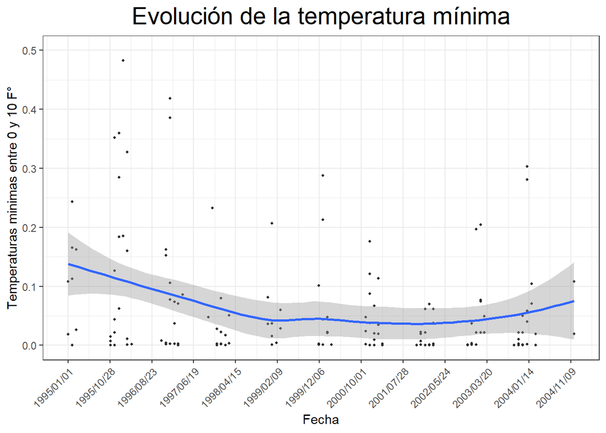

```r
#selecciono columnas a usar
db_2 <- db_1[,c(1,14,19,6,7,8,9)]

# Semas mas frias
db_21 <- db_2[!db_2$w_mina==0,]
db_22 <- db_2[db_2$w_mina>=0.3,]

# Fechas + columna ID puedo saber a que fin de semana corresponde
Dfecha <- db_1[,c(1,19,6,7,8,9)]

p <- ggplot(db_21,aes(x=Fecha, y =w_mina))+
  geom_point(color="gray17", size=0.8, alpha=1)+
  geom_smooth()+
  theme_bw()+
  scale_y_continuous(name = "Temperaturas minimas entre 0 y 10 F°",
                     labels=function(x) format(x, big.mark = ".", scientific = FALSE),
                     breaks = seq(0,0.6,0.1), lim = c(0,0.5))+
  theme(
    legend.position="none",
    plot.title = element_text(size=20)
  )+
  ggtitle(label = "Evolución de la temperatura mínima")

# Modificar las fechas para tener analisis anual
min <- as.Date("1995/01/01")
max <- as.Date("2004/12/01")

p+scale_x_date(limits = c(min,max),breaks = seq(min,max,300),date_labels = "%Y/%m/%d")+
  theme(axis.text.x = element_text(angle=45, hjust = 1))+
  theme(plot.title = element_text(hjust = 0.5))
```

```r
print(db_22)
```

```
##     wkd_ind  w_mina      Fecha h_chris h_newyr h_easter h_july4
## 48       49 0.35233 1995-12-01       0       0        0       0
## 52       53 0.35939 1996-01-01       0       0        0       0
## 56       57 0.48247 1996-02-01       0       0        0       0
## 61       62 0.32787 1996-03-01       0       0        0       0
## 105     106 0.41882 1997-01-01       0       0        0       0
## 106     107 0.38561 1997-01-01       0       0        0       0
## 469     474 0.30337 2004-01-01       0       0        0       0
```

```r
#selecciono columnas a usar
db_3 <- db_1[,c(1,13,19,6,7,8,9)]
names(db_3)
```

```
## [1] "wkd_ind"  "w_maxc"   "Fecha"    "h_chris"  "h_newyr"  "h_easter" "h_july4"
```

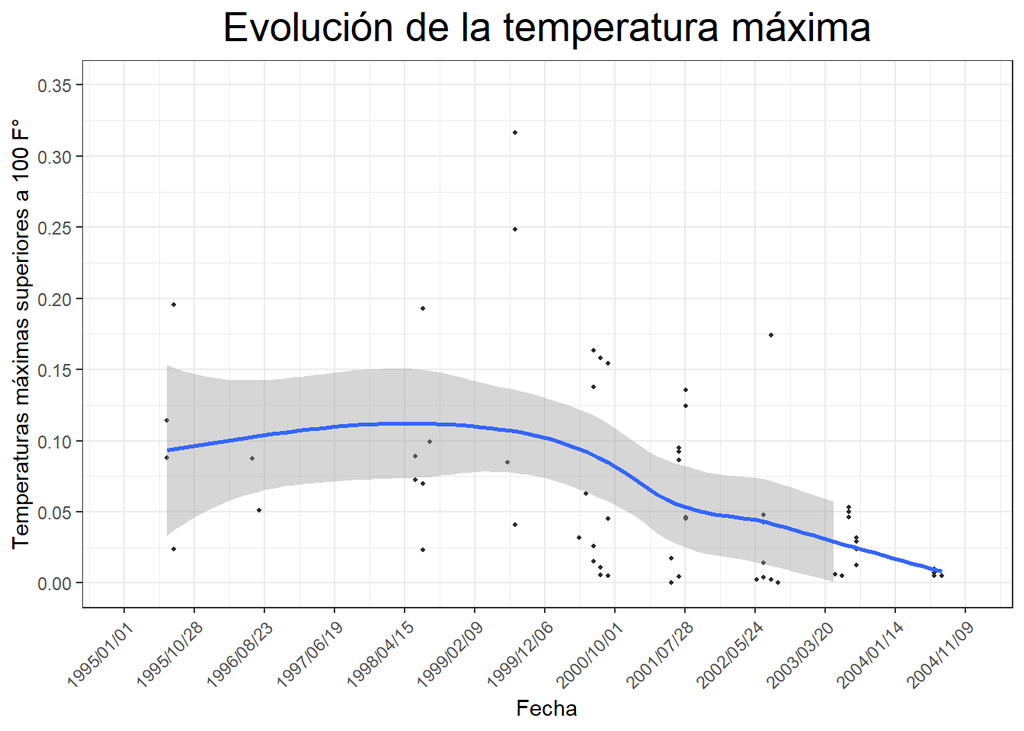

```r
# Semanas mas calurosas
db_31 <- db_3[!db_3$w_maxc==0,]
db_32 <- db_3[db_3$w_maxc>=0.17,]

# Fechas + columna ID puedo saber a que fin de semana corresponde
Dfecha <- db_1[,c(1,19,6,7,8,9)]

p <- ggplot(db_31,aes(x=Fecha, y =w_maxc))+
  geom_point(color="gray17", size=0.8, alpha=1)+
  geom_smooth()+
  theme_bw()+
  scale_y_continuous(name = "Temperaturas máximas superiores a 100 F°",
                     labels=function(x) format(x, big.mark = ".", scientific = FALSE),
                     breaks = seq(0,0.4,0.05), lim = c(0,0.35))+
  theme(
    legend.position="none",
    plot.title = element_text(size=20)
  )+
  ggtitle(label = "Evolución de la temperatura máxima")

# Modificar las fechas para tener analisis anual
min <- as.Date("1995/01/01")
max <- as.Date("2004/12/01")

p+scale_x_date(limits = c(min,max),breaks = seq(min,max,300),date_labels = "%Y/%m/%d")+
  theme(axis.text.x = element_text(angle=45, hjust = 1))+
  theme(plot.title = element_text(hjust = 0.5))
```

- 33 = *era semana 1995-08*
- 187 = *ultima semana 1998-07*
- 241 = *2da semana 1999-08*
- 242 = *era semana 1999-08*
- 399 = *penúltima semana 2002-08*

```r
print(db_32)
```

```
##     wkd_ind  w_maxc      Fecha h_chris h_newyr h_easter h_july4
## 32       33 0.19538 1995-08-01       0       0        0       0
## 186     187 0.19268 1998-07-01       0       0        0       0
## 239     241 0.31658 1999-08-01       0       0        0       0
## 240     242 0.24847 1999-08-01       0       0        0       0
## 395     399 0.17419 2002-08-01       0       0        0       0
```

### 3. ¿Cuál o cualés serían las variables relevantes u objetivos para responder a la pregunta de estudio? ¿y Por qué?(2 ptos)

```r
cat("Las variables mas importantes para responder la pregunta del estudio son: assaults, attend_v, attend_m, attend_n. Con estas variables ya se puede aceptar o rechazar la hipótesis ¿la violencia en el cine aumenta el crimen violento?\n\nEl resto de las variables pueden resultar importantes, si con las mencionadas anteriormente no encontrara una correlación significativamente alta. Dado que las variaciones del crimen violento se podrían explicar mejor por variables de festividades u estacionales.
")
```

```
## Las variables mas importantes para responder la pregunta del estudio son: assaults, attend_v, attend_m, attend_n. Con estas variables ya se puede aceptar o rechazar la hipótesis ¿la violencia en el cine aumenta el crimen violento?
##
## El resto de las variables pueden resultar importantes, si con las mencionadas anteriormente no encontrara una correlación significativamente alta. Dado que las variaciones del crimen violento se podrían explicar mejor por variables de festividades u estacionales.
```

### 4. Basado en lo anterior, identifique si existen outliers. Explique tratamiento de la información.(2 ptos)

```r
# assaults = 3 valores negativos y 3 valores demaciado altos, estos desvirtuan el analisis
# y por lo tanto seran eliminados del mismo
db_4_assaults <- db %>%
    group_by(assaults) %>%
    count(assaults)

# attend_v = 4 valores inf que pueden ser infinitos positivos o valores indefinidos.
db_4_attend_v <- db %>%
    group_by(attend_v) %>%
    count(attend_v)

db_4_attend_m <- db %>%
    group_by(attend_m) %>%
    count(attend_m)

db_4_attend_n <- db %>%
    group_by(attend_n) %>%
    count(attend_n)

cat("De las variables relevantes assaults tiene 3 valores negativos y 3 valores demasiado altos, estos desvirtúan el análisis y por lo tanto serán eliminados. Además, no tiene sentido un numero de asaltos negativos o un momento del tiempo en estados unidos con un crecimiento tan alto de eventos de violencia, este tipo de suceso estaría documentado y no se encontró evidencia. Por lo tanto, se entienden como errores.\n\nAsimismo attend_v tiene 4 valores inf que pueden ser infinitos positivos o valores indefinidos, estos se eliminaran del análisis dado que no permiten darle formato numérico a la variable y ademas desvirtúan el análisis.")
```

[output not shown]

### 5. Genere una matriz de correlaciones, con al menos 4 variables.*hint: incluya las que son el objetivo de estudio*. Explique los resultados.(2 ptos)

```r
# Selecciono formato numerico, en necesario correr pregunta 1
db_Vrelevantes_2 <- db_Vrelevantes_2[db_Vrelevantes_2$assaults<12000,]
db_1_correlacion <- db_Vrelevantes_2[,sapply(db_Vrelevantes_2, is.numeric)]
names(db_1_correlacion)
```

```
## [1] "assaults" "attend_v" "attend_m" "attend_n"
```

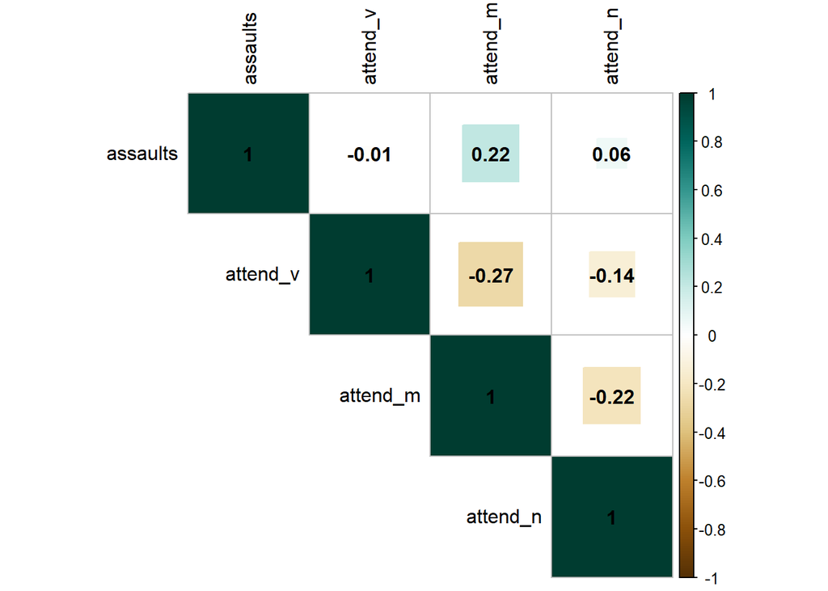

```r
#Matriz de correlacion
res <- cor(db_1_correlacion, use = "pairwise.complete.obs",
method = "pearson")

corrplot(res[,c(1:4)], type = "upper", method= "square", tl.col = "black",addCoef.col = 'black', col = COL2('BrBG'))
```

Podemos empezar a intuir que las películas que contienen violencia no guardan relación con el numero de asaltos e intimidaciones.

### 6. Genere tres gráficos de dispersión con la respectiva línea de tendencia, y determine si la correlación de estas variables es significativa.(3 ptos)

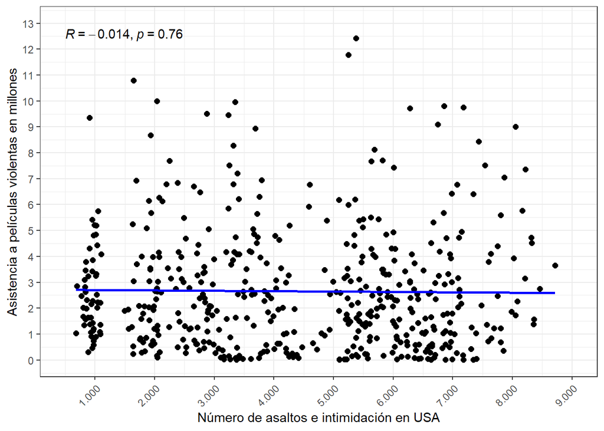

```r
#Grafico 1
db_dispercion <- db_Vrelevantes_2


sp <- ggscatter(db_dispercion, x = "assaults" , y = "attend_v",
                add = "reg.line",
                add.params = list(color = "blue", fill = "lightgray"),
                conf.int = FALSE)
sp+stat_cor(method = "pearson")+
  theme_bw()+
  scale_y_continuous(name = "Asistencia a películas violentas en millones",
                     labels=function(x) format(x, big.mark = ".", scientific = FALSE),
                     breaks = seq(0,13,1), lim = c(0,13)
                     )+
  scale_x_continuous(name = "Número de asaltos e intimidación en USA",
                     labels=function(x) format(x, big.mark = ".", scientific = FALSE),
                     breaks = seq(0,10000,1000), lim = c(500,9000)
                     )+
  theme(axis.text.x = element_text(angle=45, hjust = 1))
```

Dado que el p-valor no es menor a 0.05, No rechazo la nula y entonces no es posible afirmar que la correlación de assaults y attend_v es significativa

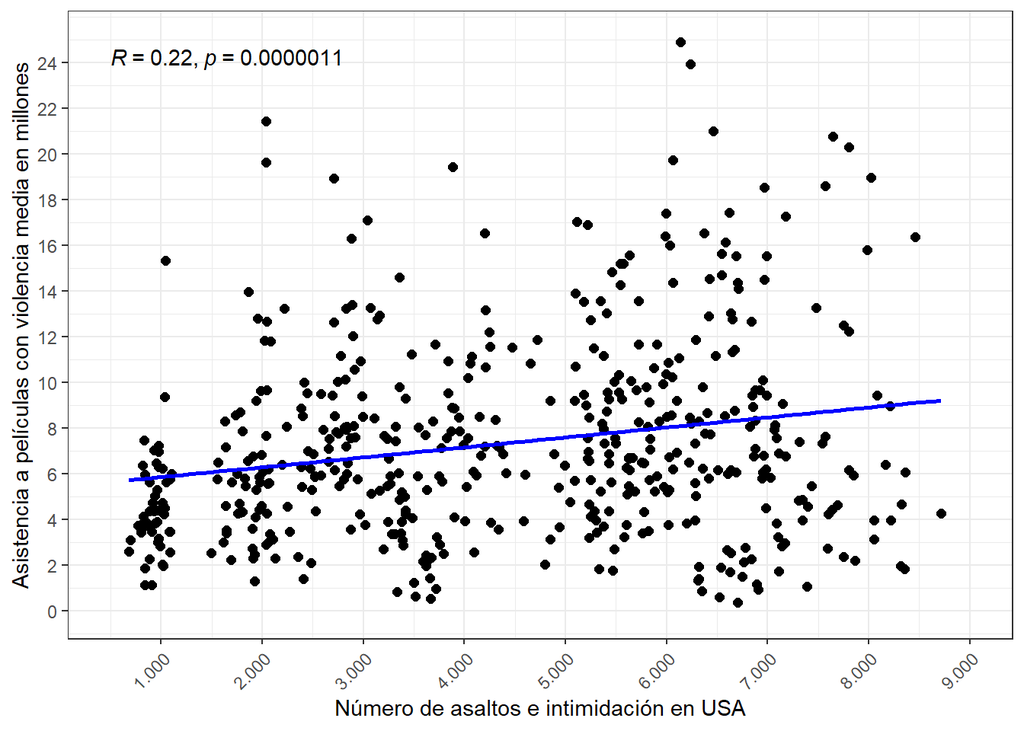

```r
#Grafico 2
sp_2 <- ggscatter(db_dispercion, x = "assaults" , y = "attend_m",
                add = "reg.line",
                add.params = list(color = "blue", fill = "lightgray"),
                conf.int = FALSE)
sp_2+stat_cor(method = "pearson")+
  theme_bw()+
  scale_y_continuous(name = "Asistencia a películas con violencia media en millones",
                     labels=function(x) format(x, big.mark = ".", scientific = FALSE),
                     breaks = seq(0,25,2), lim = c(0,25)
                     )+
  scale_x_continuous(name = "Número de asaltos e intimidación en USA",
                     labels=function(x) format(x, big.mark = ".", scientific = FALSE),
                     breaks = seq(0,10000,1000), lim = c(500,9000)
                     )+
  theme(axis.text.x = element_text(angle=45, hjust = 1))
```

Dado que el p-valor es menor a 0.05, rechazo la nula y entonces es posible afirmar que la correlación de assaults y attend_m es significativa

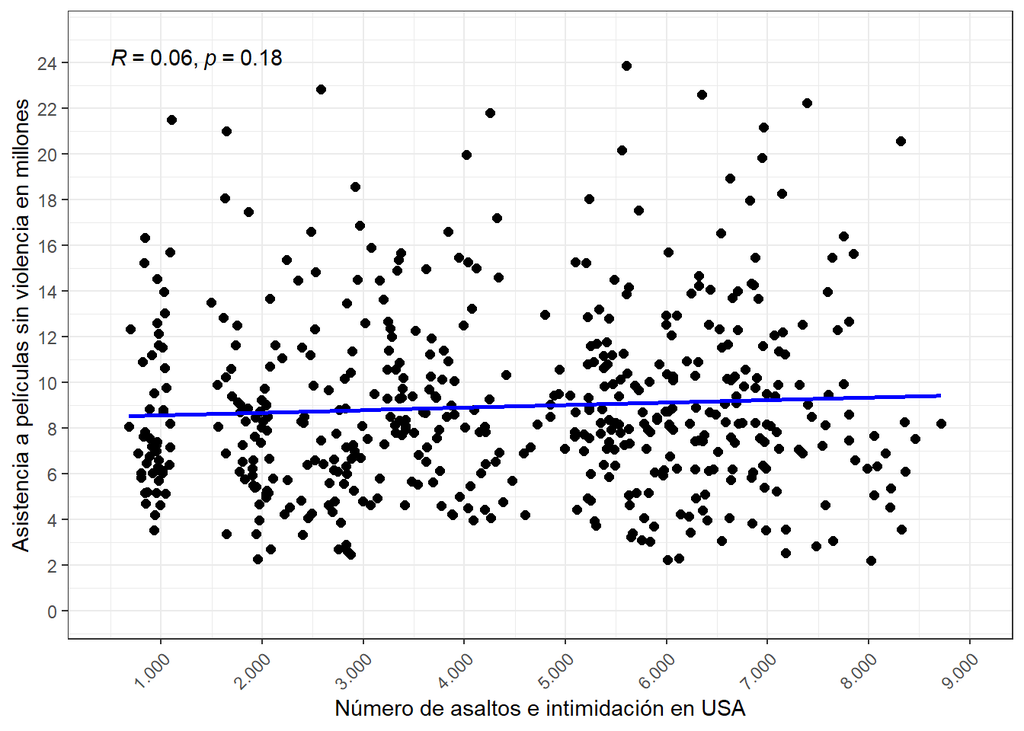

```r
#Grafico 3
sp_3 <- ggscatter(db_dispercion, x = "assaults" , y = "attend_n",
                add = "reg.line",
                add.params = list(color = "blue", fill = "lightgray"),
                conf.int = FALSE)
sp_3+stat_cor(method = "pearson")+
  theme_bw()+
  scale_y_continuous(name = "Asistencia a películas sin violencia en millones",
                     labels=function(x) format(x, big.mark = ".", scientific = FALSE),
                     breaks = seq(0,25,2), lim = c(0,25)
                     )+
  scale_x_continuous(name = "Número de asaltos e intimidación en USA",
                     labels=function(x) format(x, big.mark = ".", scientific = FALSE),
                     breaks = seq(0,10000,1000), lim = c(500,9000)
                     )+
  theme(axis.text.x = element_text(angle=45, hjust = 1))
```

Dado que el p-valor no es menor a 0.05, No rechazo la nula y entonces no es posible afirmar que la correlación de assaults y attend_n es significativa

### 7. Escoja una de las variables en procentajes, explique por qué sería interesante incoporarla a este esudio.(1 pto)

Ninguna de las variables climáticas que son las expresadas en porcentaje ayudaría mucho a dar respuesta a la pregunta del estudio, pero sería interesante Agregar la variable w_maxc, que indica la fracción de lugares con una temperatura diaria de mas de 100°F, algo así como 38° grados Celsius. Esto con la intención de demostrar como objetivo secundario que a mayores temperaturas disminuyen la cantidad de asaltos e intimidaciones. Se debería observar una correlación negativa.

### 8. Genere un box plot que permita determinar si el fin de semana de navidad tiene influencia en el número de asaltos. Explique sus resultados.(2 ptos)

```r
names(db_1)
```

```
##  [1] "wkd_ind"  "assaults" "attend_v" "attend_m" "attend_n" "h_chris"
##  [7] "h_newyr"  "h_easter" "h_july4"  "h_labor"  "w_maxa"   "w_maxb"
## [13] "w_maxc"   "w_mina"   "w_minb"   "w_minc"   "w_rain"   "w_snow"
## [19] "Fecha"
```

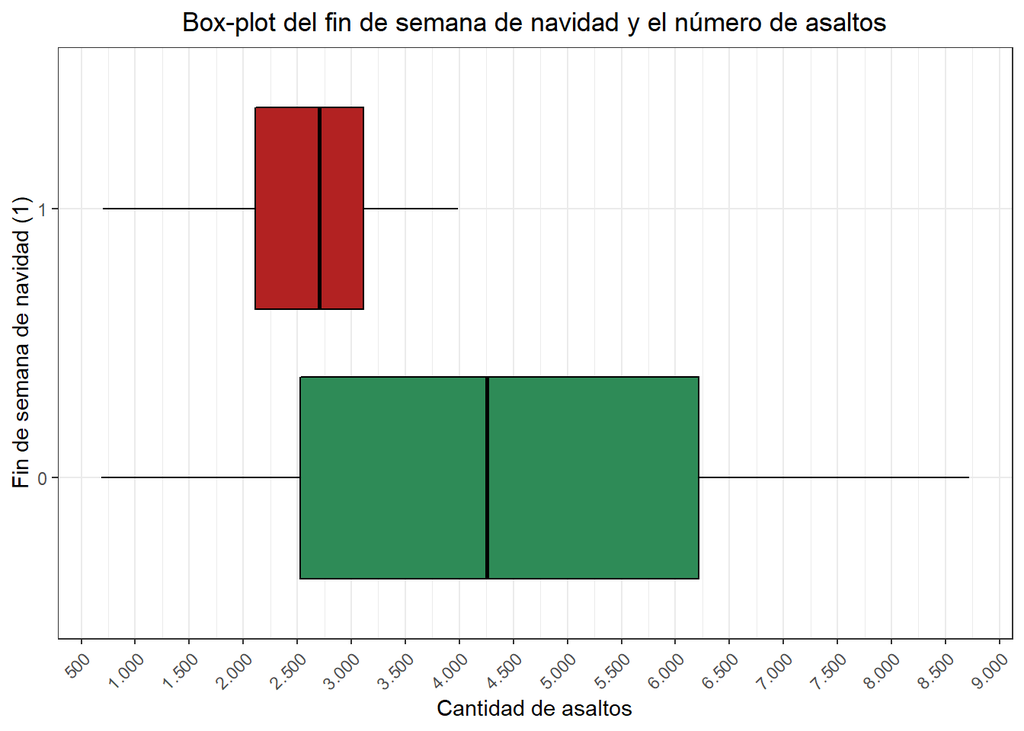

```r
db_pregunta8 <- db_1[!db_1$assaults>12000,]
db_pregunta8 <- db_pregunta8[!db_pregunta8$assaults<0,]


ggplot(db_pregunta8, aes(x=factor(h_chris), y=assaults)) +
  geom_boxplot(fill=c("seagreen","firebrick"),
               color="black")+
  scale_y_continuous(breaks = seq (from = 0, to = 20000, by = 500),
                     labels=function(x) format(x, big.mark = ".", scientific = FALSE))+
  coord_flip()+
  theme_bw()+
  labs(title = "Box-plot del fin de semana de navidad y el número de asaltos",
       x = "Fin de semana de navidad (1)",
       y = "Cantidad de asaltos")+
  theme(axis.text.x = element_text(angle=45, hjust = 1))+
  theme(plot.title = element_text(hjust = 0.5))
```

En el box plot presentado hay que establecer en 1er lugar que existe una cantidad mucho menor de fines de semana de navidad, las cuales se estan evaluando contra el resto de la muestra. Podemos decir que los fines de semana de navidad se observa una cantidad mucho menor de asaltos, dado que la mediana de los fines de semana de navidad esta casi al mismo nivel que el percentil 25 del resto de la muestra. También podemos mencionar que la dispersión de los datos es mucho mayor en los que no son fines de semana navoidad, aunque esto se debe a la gran diferencia en el tamaño de la muestra. Finalmente es destacable que el percentil 100 de los fines de semana de navidad no alcanza la mediana del resto de la muestra.

### 9. Genere un boxplot que muestre la distribución de asistencia a películas violentas por año. Explique sus resultados. (2 ptos)

```r
library("stringr")

db_pregunta9 <- db_pregunta8
db_pregunta9$Fecha <- as.character(db_pregunta9$Fecha)
db_pregunta9$anio <- str_trunc(db_pregunta9$Fecha,7,"right")

db_pregunta9_1 <- db_pregunta9 %>%
    group_by(anio) %>%
    count(anio)

db_pregunta9$anio <- gsub("1995...","1995",db_pregunta9$anio)
db_pregunta9$anio <- gsub("1996...","1996",db_pregunta9$anio)
db_pregunta9$anio <- gsub("1997...","1997",db_pregunta9$anio)
db_pregunta9$anio <- gsub("1998...","1998",db_pregunta9$anio)
db_pregunta9$anio <- gsub("1999...","1999",db_pregunta9$anio)
db_pregunta9$anio <- gsub("2000...","2000",db_pregunta9$anio)
db_pregunta9$anio <- gsub("2001...","2001",db_pregunta9$anio)
db_pregunta9$anio <- gsub("2002...","2002",db_pregunta9$anio)
db_pregunta9$anio <- gsub("2003...","2003",db_pregunta9$anio)
db_pregunta9$anio <- gsub("2004...","2004",db_pregunta9$anio)


names(db_pregunta9)
```

```
##  [1] "wkd_ind"  "assaults" "attend_v" "attend_m" "attend_n" "h_chris"
##  [7] "h_newyr"  "h_easter" "h_july4"  "h_labor"  "w_maxa"   "w_maxb"
## [13] "w_maxc"   "w_mina"   "w_minb"   "w_minc"   "w_rain"   "w_snow"
## [19] "Fecha"    "anio"
```

```r
head(db_pregunta9)
```

```
##   wkd_ind assaults attend_v attend_m attend_n h_chris h_newyr h_easter h_july4
## 1       2     1037   4.4302   4.5009  13.0200       0       0        0       0
## 2       3      827   3.0914   4.1061   7.6340       0       0        0       0
## 3       4      864   2.3211   3.8242   5.1748       0       0        0       0
## 4       5      801   2.0207   3.4072   6.0123       0       0        0       0
## 5       6      802   1.6774   3.7537   5.8236       0       0        0       0
## 6       7      931   1.6346   4.3510   9.5369       0       0        0       0
##   h_labor w_maxa w_maxb w_maxc   w_mina   w_minb  w_minc  w_rain  w_snow
## 1       0      0      0      0 0.000000 0.140680 0.23946 0.50969 0.32722
## 2       0      0      0      0 0.018884 0.317690 0.33483 0.24992 0.38456
## 3       0      0      0      0 0.107980 0.250900 0.45507 0.29066 0.36041
## 4       0      0      0      0 0.165540 0.206550 0.42418 0.28971 0.22387
## 5       0      0      0      0 0.243300 0.089456 0.35927 0.30817 0.34644
## 6       0      0      0      0 0.112740 0.125140 0.31222 0.36490 0.20611
##        Fecha anio
## 1 1995-01-01 1995
## 2 1995-01-01 1995
## 3 1995-01-01 1995
## 4 1995-02-01 1995
## 5 1995-02-01 1995
## 6 1995-02-01 1995
```

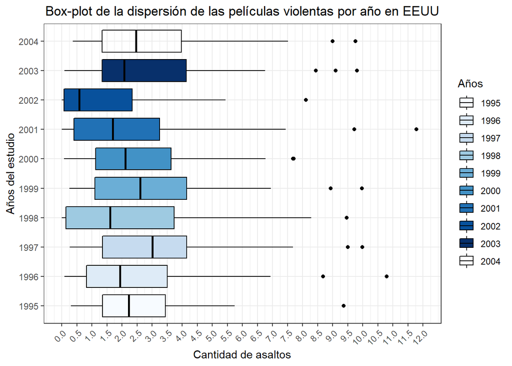

```r
ggplot(db_pregunta9, aes(x=factor(anio), y=attend_v, fill=factor(anio))) +
  geom_boxplot(color="black")+
  scale_y_continuous(breaks = seq (from = 0, to = 12, by = 0.5),
                     labels=function(x) format(x, big.mark = ".", scientific = FALSE),
                     limits = c(0,12))+
  coord_flip()+
  theme_bw()+
  labs(title = "Box-plot de la dispersión de las películas violentas por año en EEUU",
       x = "Años del estudio",
       y = "Cantidad de asaltos")+
  theme(plot.title = element_text(hjust = 0.5))+
  scale_fill_brewer("Años")+
  theme(axis.text.x = element_text(angle=45, hjust = 1))
```

El box-plot presenta la dispersión de la asistencia a películas violentas en usa, podemos observar que en el año 1997 se observa la asistencia por mediana más alta y en el 2002 la mas baja. Podemos destacar también que para el año 2002 el percentil 75 no alcanza a llegar a la mediana de los años 1999 y 1997, los cuales por su mediana y percentil 75 parecen ser los años con mayor asistencia a películas violentas. Mientras tanto el año 1998 presenta la mayor dispersión de los datos y el año 1995 junto con el 2002 presentan la menor dispersión.

### 10. Corra la siguiente regresión multiple, ¿Qué puede decir respecto a su R cuadrado?(1 pto)

```r
names(db_pregunta8)
```

```
##  [1] "wkd_ind"  "assaults" "attend_v" "attend_m" "attend_n" "h_chris"
##  [7] "h_newyr"  "h_easter" "h_july4"  "h_labor"  "w_maxa"   "w_maxb"
## [13] "w_maxc"   "w_mina"   "w_minb"   "w_minc"   "w_rain"   "w_snow"
## [19] "Fecha"
```

```r
regr1 <- lm(assaults ~ attend_v+factor(h_july4), data = db_pregunta8, na.action = na.omit)
summary(regr1)
```

```
##
## Call:
## lm(formula = assaults ~ attend_v + factor(h_july4), data = db_pregunta8,
##     na.action = na.omit)
##
## Residuals:
##     Min      1Q  Median      3Q     Max
## -3684.7 -1846.4  -144.7  1833.5  4400.5
##
## Coefficients:
##                  Estimate Std. Error t value            Pr(>|t|)
## (Intercept)       4387.14     144.50  30.362 <0.0000000000000002 ***
## attend_v           -18.78      41.56  -0.452               0.651
## factor(h_july4)1   928.06     960.07   0.967               0.334
## ---
## Signif. codes:  0 '***' 0.001 '**' 0.01 '*' 0.05 '.' 0.1 ' ' 1
##
## Residual standard error: 2134 on 503 degrees of freedom
## Multiple R-squared:  0.002181,   Adjusted R-squared:  -0.001786
## F-statistic: 0.5497 on 2 and 503 DF,  p-value: 0.5774
```

Dado que es una regresión lineal con 2 variables explicativas o múltiple se usa el R cuadrado ajustado, dado que el Rcuadrado pierde grados de libertad y por lo tanto su valor queda sobreestimado. Podemos decir del R cuadrado ajustado que en suma la asistencia a películas violentas y la variable dummy de los fines de semana del 4 de julio explica de forma inversa en un 0.1786% a la variable numero de asaltos e intimidaciones en USA.

### 11.Corra la siguiente regresión multiple, ¿ Qué puede decir respecto a su R cuadrado? (1 pto)

```r
regr2 <- lm(assaults ~ attend_v+attend_m+factor(h_july4), data = db_pregunta8, na.action = na.omit)
summary(regr2)
```

```
##
## Call:
## lm(formula = assaults ~ attend_v + attend_m + factor(h_july4),
##     data = db_pregunta8, na.action = na.omit)
##
## Residuals:
##     Min      1Q  Median      3Q     Max
## -4189.2 -1792.0   -64.1  1697.3  4686.2
##
## Coefficients:
##                  Estimate Std. Error t value             Pr(>|t|)
## (Intercept)       3404.12     241.82  14.077 < 0.0000000000000002 ***
## attend_v            41.45      42.34   0.979                0.328
## attend_m           113.32      22.64   5.006          0.000000769 ***
## factor(h_july4)1   367.04     944.57   0.389                0.698
## ---
## Signif. codes:  0 '***' 0.001 '**' 0.01 '*' 0.05 '.' 0.1 ' ' 1
##
## Residual standard error: 2084 on 502 degrees of freedom
## Multiple R-squared:  0.04963,    Adjusted R-squared:  0.04395
## F-statistic: 8.739 on 3 and 502 DF,  p-value: 0.00001168
```

Dado que es una regresión lineal con 2 variables explicativas o múltiple se usa el R cuadrado ajustado, dado que el Rcuadrado pierde grados de libertad y por lo tanto su valor queda sobreestimado. Podemos decir del R cuadrado ajustado que en suma la asistencia a películas violentas, de mediana violencia y la variable dummy de los fines de semana del 4 de julio, forman un modelo que explica de forma en un 4.395 % a la variable numero de asaltos e intimidaciones en USA.

### 12. ¿Cuál de los dos modelos anteriores es mejor (pregunta 10 y 11)? ¿Por qué? (1 pto)

El modelo de la pregunta 11 es mejor porque explica mucho mas el comportamiento de la variable número de asaltos e intimidaciones en USA, además el p valor nos indica que en el modelo de la pregunta 11 rechazamos la nula dado que es menor a 0.05 y por lo tanto el modelo es significativo. Además, el F estadístico es superior a 3.6 por lo cual se confirma que el modelo de la pregunta 11 es mucho mejor al de la pregunta 10 que no cumple con ninguna de las anteriores características.

### 13. Genere una regresión lineal a su gusto, que cumpla con la condición que integre una variable de *edad promedio* de las personas que asisten por semana al cine y que esta se integre de manera lineal y cuadrática (edad+ edad2) al modelo, ocupe la función de preferencia para contruirla. Además, esta regresión debe tener mayor R cuadrado que los dos modelos anteriores, respetando siempre que *assaults* sea la variable dependiente. (2 ptos)

```r
db_pregunta13 <- db_pregunta8

edad <- sample(1:97,506,replace=TRUE)
edad <- as.data.frame(edad)
db_pregunta13 <- merge(db_pregunta13,edad)
db_pregunta13$edad_2 <- db_pregunta13[,"edad"]*db_pregunta13[,"edad"]

regr3 <- lm(assaults ~ attend_v+attend_m+edad+edad_2, data = db_pregunta13, na.action = na.omit)
summary(regr3)
```

```
##
## Call:
## lm(formula = assaults ~ attend_v + attend_m + edad + edad_2,
##     data = db_pregunta13, na.action = na.omit)
##
## Residuals:
##    Min     1Q Median     3Q    Max
##  -4201  -1800    -65   1698   4690
##
## Coefficients:
##                               Estimate                 Std. Error t value
## (Intercept) 3396.680934932777290669037   15.911310815798730189385  213.48
## attend_v      42.755308636001302602381    1.869361486043107367649   22.87
## attend_m     114.365600355819978517502    0.995354188436124331929  114.90
## edad          -0.000000000000196006099    0.589589311474601585061    0.00
## edad_2        -0.000000000000000007648    0.005820556656971164269    0.00
##                        Pr(>|t|)
## (Intercept) <0.0000000000000002 ***
## attend_v    <0.0000000000000002 ***
## attend_m    <0.0000000000000002 ***
## edad                          1
## edad_2                        1
## ---
## Signif. codes:  0 '***' 0.001 '**' 0.01 '*' 0.05 '.' 0.1 ' ' 1
##
## Residual standard error: 2077 on 256031 degrees of freedom
## Multiple R-squared:  0.04935,    Adjusted R-squared:  0.04933
## F-statistic:  3323 on 4 and 256031 DF,  p-value: < 0.00000000000000022
```

### 14. ¿Usted cree que es correcto correr una regresión para este tipo de estructura de datos?¿Por qué si o por qué no? (1 pto)

```r
cat("Aplicar una regresión a estudios con datos de panel como este tiene una complejidad desde el punto de vista de los supuestos del modelo, dado que para las regresiones se busca que no exista autocorrelación en los errores y esta base de datos fue tomada a lo largo de 10 años, por lo cual no se puede descartar la presencia de autocorrelación en sus variables, es decir, que estas se expliquen a si mismas.\n\nEsta distinción se hace para los modelos de corte transversal y longitudinal, donde para los últimos se aplican modelos autorregresivos, y para los de corte transversal se usa MCO u otros en donde el tiempo no juega un rol importante.\n\nSin embargo, dado que esta base de datos no sigue a un mismo grupo de individuos tendría que testear los supuestos del modelo para saber si una regresión lineal es un buen modelo o no.\n\nDejando de lado lo anterior y analizándolo desde el punto de vista de las variables no considero que sea un buen modelo el intentar predecir el numero de asaltos o intimidaciones con la visualización de películas, dado que no existen altas correlaciones y no considero que la intuición de las variables sea lógica. Las características climáticas podrían predecir de mejor manera a la variable del estudio.
")
```

[output not shown]